# ARTF-TPM - Project Deviations Report

EERA-WASH

28 July, 2025

## Current Deviation Status

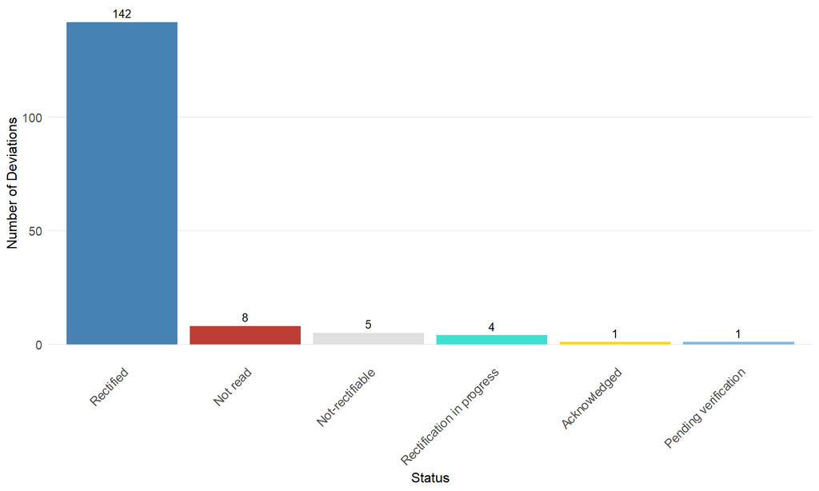

|  | Status | Count | Percentage (%) |
| --- | --- | --- | --- |
| 1 | Rectified | 142 | 88.2 |
| 2 | Not read | 8 | 5 |
| 3 | Not-rectifiable | 5 | 3.1 |
| 4 | Rectification in progress | 4 | 2.5 |
| 5 | Acknowledged | 1 | 0.6 |
| 6 | Pending verification | 1 | 0.6 |

## Deviation Type

**Click here to view Deviation Type definitions**

**Minor Deviations** - Capable of being rectified within the existing budget and/or timeframe for completion - No significant negative impact in terms of overall structural quality, functionality, and/or sustainability - Not capable of being rectified but has no negative effect on the agreed budget and timeframe for completion.

**Major Deviations** - Capable of being rectified but not within the existing budget and/or timeframe for completion - A significant negative impact in terms of overall structural quality, functionality, and/or sustainability - Not capable of being rectified and resulting in the agreed budget and timeframe for completion being exceeded - Part of the sub-project is non-operational due to recoverable/non-recoverable issues - Failure to construct the part of the sub-project on-site.

**Critical Deviations** - Failure to construct infrastructure in a way that risks the safety or lives of workers or community members during construction and requires urgent mitigation before work can continue - For completed infrastructure, failure to construct infrastructure in a way that is likely to risk the safety or lives of community members or users - A non-recoverable negative impact in terms of structural quality, functionality, or sustainability - Sub-project is non-operational due to recoverable/non-recoverable issues - Failure to construct the sub-project or part of the sub-project on-site.

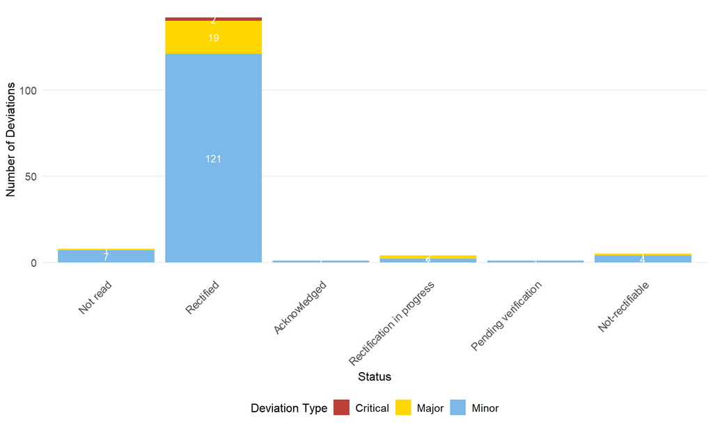

|  | Deviation Type | Status | Count | % of Type | % of Total |
| --- | --- | --- | --- | --- | --- |
| 1 | Critical | Rectified | 2 | 100 | 1.2 |
| 2 | Major | Not read | 1 | 4.3 | 0.6 |
| 3 | Major | Not-rectifiable | 1 | 4.3 | 0.6 |
| 4 | Major | Rectification in progress | 2 | 8.7 | 1.2 |
| 5 | Major | Rectified | 19 | 82.6 | 11.8 |
| 6 | Minor | Acknowledged | 1 | 0.7 | 0.6 |
| 7 | Minor | Not read | 7 | 5.1 | 4.3 |
| 8 | Minor | Not-rectifiable | 4 | 2.9 | 2.5 |
| 9 | Minor | Pending verification | 1 | 0.7 | 0.6 |
| 10 | Minor | Rectification in progress | 2 | 1.5 | 1.2 |

[output cut: 1 more lines]

## Deviation Aspect Type

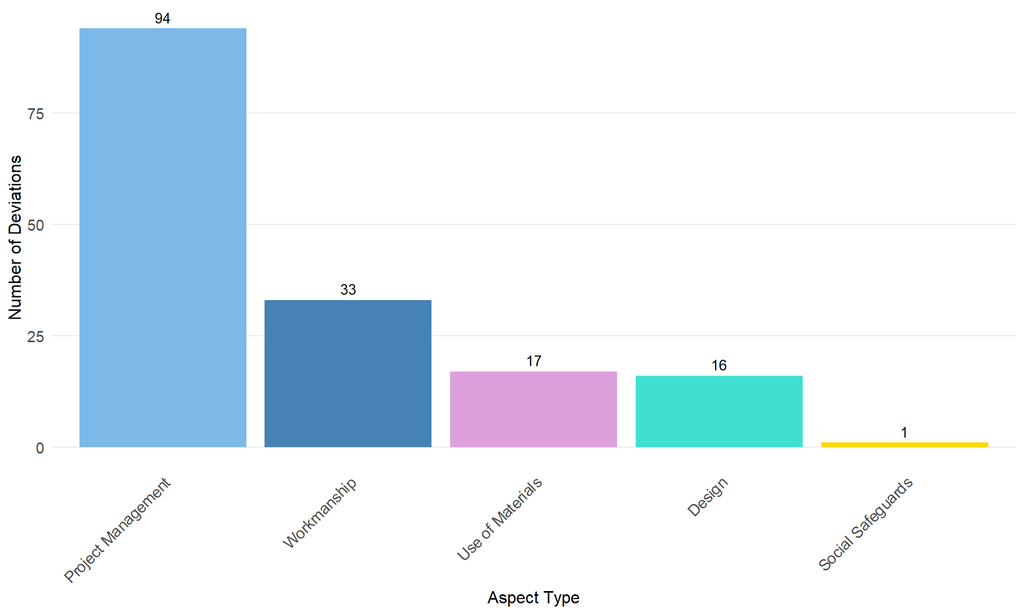

|  | Aspect Type | Count | Percentage (%) |
| --- | --- | --- | --- |
| 1 | Project Management | 94 | 58.4 |
| 2 | Workmanship | 33 | 20.5 |
| 3 | Use of Materials | 17 | 10.6 |
| 4 | Design | 16 | 9.9 |
| 5 | Social Safeguards | 1 | 0.6 |

## Monthly Trend Analysis

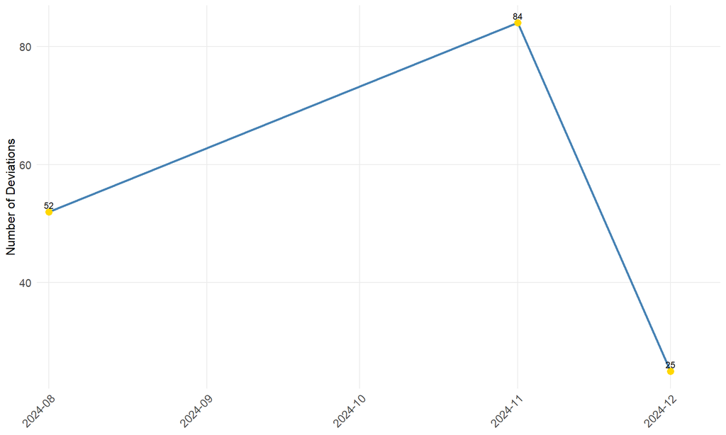

## Deviation Status Over Time

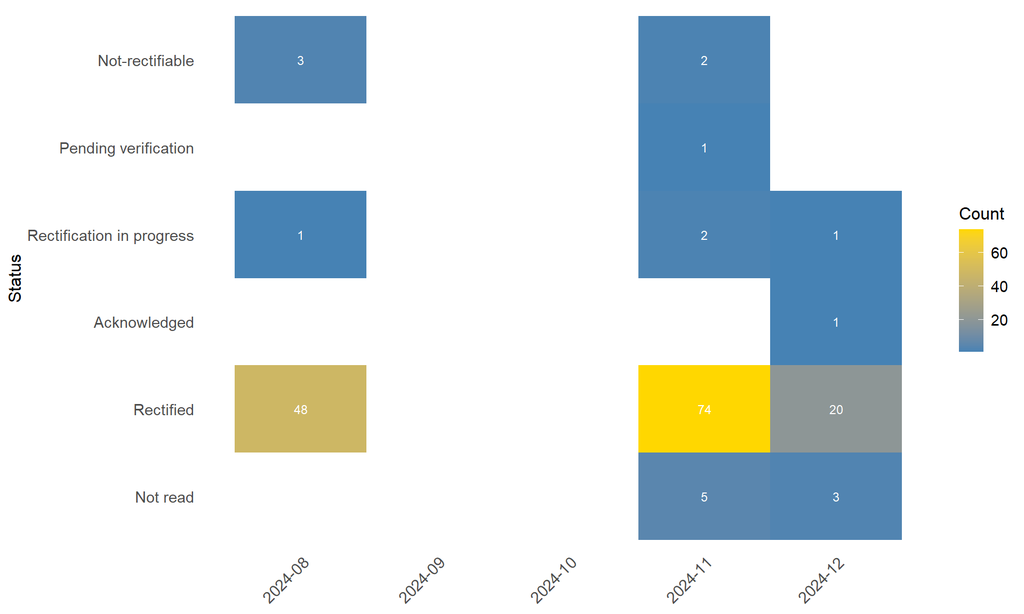

## Detailed Monthly Summary

|  | Year | Month | Status | Count | % of Month Total |
| --- | --- | --- | --- | --- | --- |
| 1 | 2024 | Aug | Not-rectifiable | 3 | 5.8 |
| 2 | 2024 | Aug | Rectification in progress | 1 | 1.9 |
| 3 | 2024 | Aug | Rectified | 48 | 92.3 |
| 4 | 2024 | Nov | Not read | 5 | 6 |
| 5 | 2024 | Nov | Not-rectifiable | 2 | 2.4 |
| 6 | 2024 | Nov | Pending verification | 1 | 1.2 |
| 7 | 2024 | Nov | Rectification in progress | 2 | 2.4 |
| 8 | 2024 | Nov | Rectified | 74 | 88.1 |
| 9 | 2024 | Dec | Acknowledged | 1 | 4 |
| 10 | 2024 | Dec | Not read | 3 | 12 |

[output cut: 2 more lines]

## Deviation Type Analysis by Month

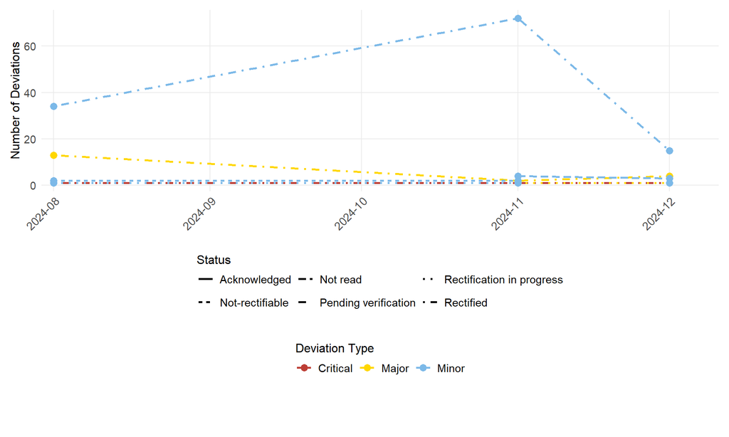

## Deviation Type Over Time

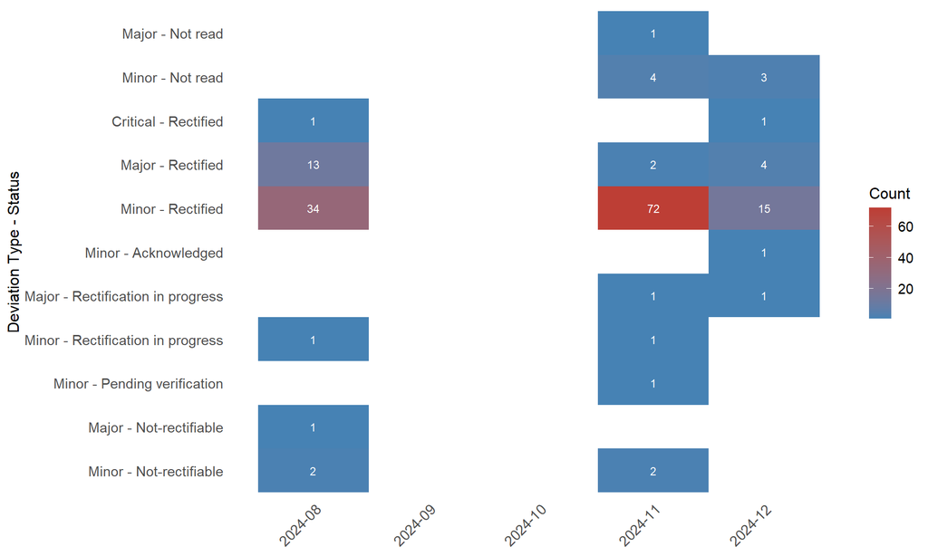

## Detailed Deviation Type Summary by Month

|  | Year | Month | Deviation Type | Status | Count | % of Month Total |
| --- | --- | --- | --- | --- | --- | --- |
| 1 | 2024 | Aug | Critical | Rectified | 1 | 1.9 |
| 2 | 2024 | Aug | Major | Not-rectifiable | 1 | 1.9 |
| 3 | 2024 | Aug | Major | Rectified | 13 | 25 |
| 4 | 2024 | Aug | Minor | Not-rectifiable | 2 | 3.8 |
| 5 | 2024 | Aug | Minor | Rectification in progress | 1 | 1.9 |
| 6 | 2024 | Aug | Minor | Rectified | 34 | 65.4 |
| 7 | 2024 | Nov | Major | Not read | 1 | 1.2 |
| 8 | 2024 | Nov | Major | Rectification in progress | 1 | 1.2 |
| 9 | 2024 | Nov | Major | Rectified | 2 | 2.4 |
| 10 | 2024 | Nov | Minor | Not read | 4 | 4.8 |

[output cut: 10 more lines]